# BaitCap Analysis

Jessica Rowell

12/11/2020

## Taking a look at the data

Our outcome variable of interest is the ratio of STEC reads to commensal reads. We want to compare this value for baitcap vs. shotgun sequencing. We want to account for the effect, if any, of replicate number, given the wet lab methodology.

First we visually check whether our outcome variable is normally distributed in our dataset. These look reasonable, especially considering the small number of observations (n = 12). For the QQ plot, the points should fall within the gray area, preferably as close to the line as possible. For the density plot, we’re looking for a nice “normal looking” curve, without much skew or bumps.

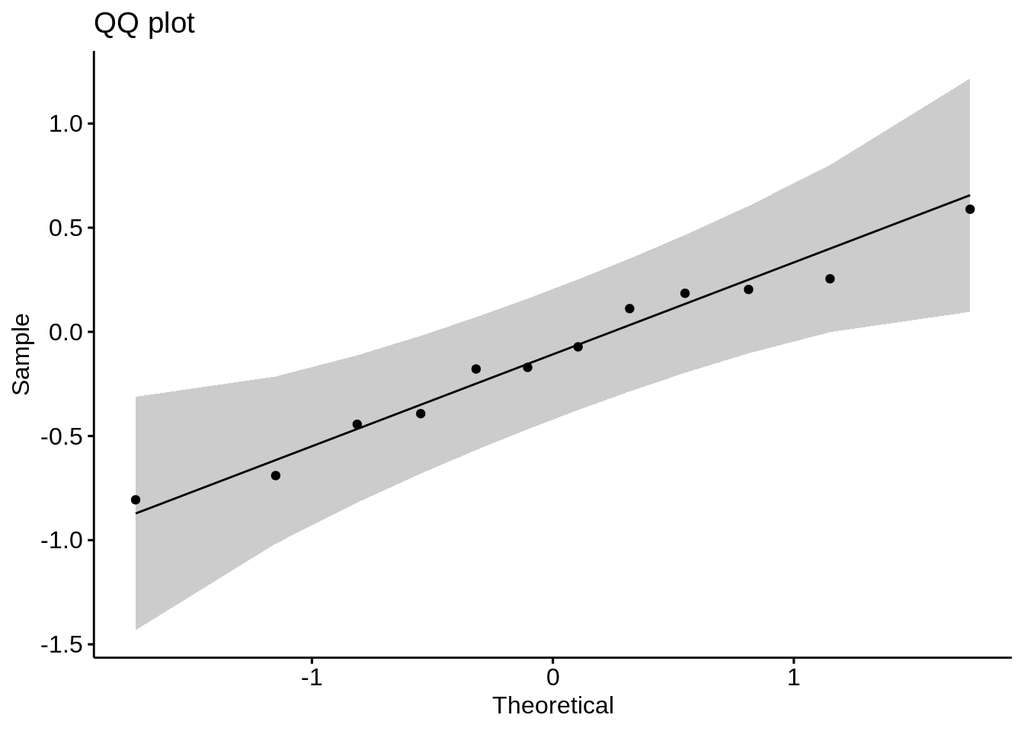

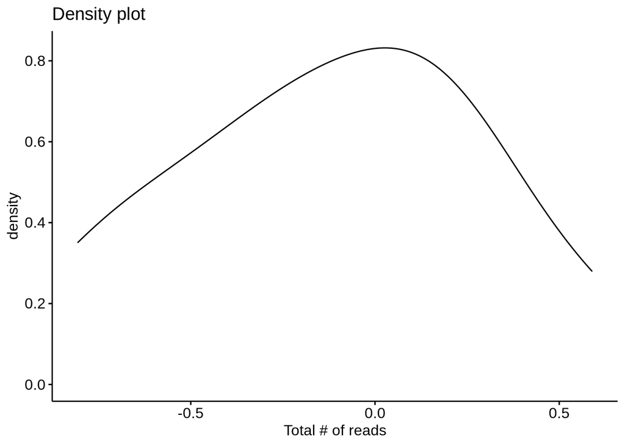

We may want to satiate our curiosity by taking a quick look at how our outcome of interest compares for baitcap vs. shotgun. Here our outcome of interest is the ratio of total number of reads for STEC vs. commensal. In the plots below, the bold line in the box is the median and the box represents the interquartile range. So the middle half of the data resides within the box. The lines extend to cover 99.3% of the data. Any dots outside the lines are outliers. Very long boxes indicate a large variance, and low precision. For our small number of observations, a larger variance is not unexpected.

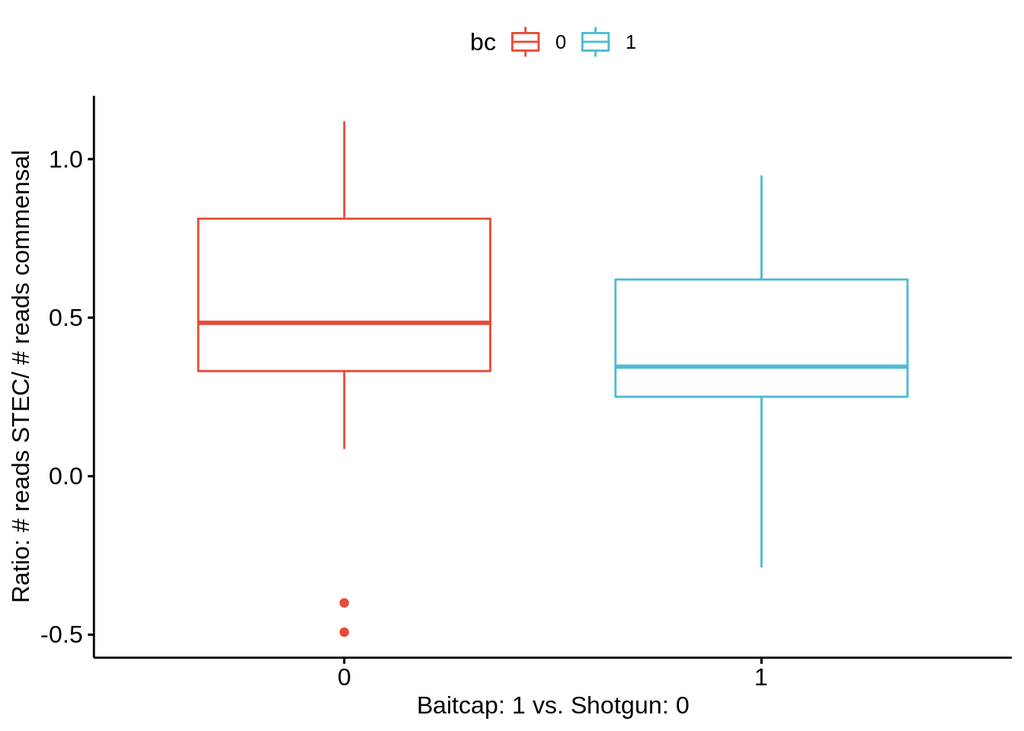

Now we visually check the distribution of that same ratio (# reads STEC vs. # reads commensal) across replicate number. While the medians are consistent across replicates, there is more variability in replicates 1 and 3 and the distributions look different.

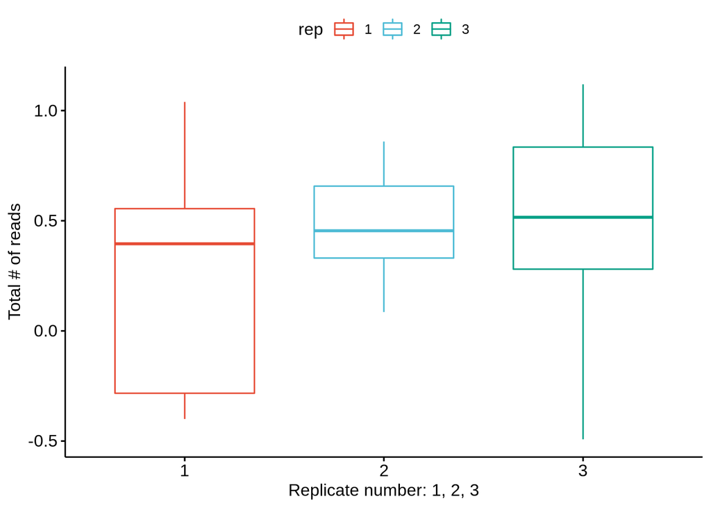

## First linear regression analysis: assume 12 independent samples

In this first analysis, we will treat the replicates as biological samples. So, we have 4 different biological sample comparisons: C2 vs. C1, F vs. C1, K vs. C1, N vs. C1. For each of those, there are 3 replicates.

Let’s call our outcome “z”. Z is the **difference** of the ratio of STEC-to-commensal for baitcap vs. shotgun. For analysis the ratios are log-transformed (as you see below).

$$y = \frac{reads_{STEC}}{reads_{commensal}}$$

$$z = \log (y_{baitcap}) - \log (y_{shotgun})$$

If we first consider each replicate as a separate, independent sample, we can just observe the average of z ($\mu_z$) in our whole dataset. This is equivalent to saying we did 12 separate tests of baitcap vs. shotgun, and we want to see what’s our best estimate of “z”.

The line we are fitting looks like this:

$$Z_i = \beta_0 + \epsilon, \space \space \space i = 1,2,...,12$$
Some details to note: the residuals are not randomly distributed. Observations 6 and 10 could be influential. These two observations correspond to F vs. C1 (replicate 3) and N vs. C1 (replicate 1).

```
##
## Call:
## lm(formula = z ~ 1, data = d4)
##
## Residuals:
##      Min       1Q   Median       3Q      Max
## -0.68874 -0.28792 -0.00384  0.30722  0.70609
##
## Coefficients:
##             Estimate Std. Error t value Pr(>|t|)
## (Intercept)  -0.1175     0.1192  -0.986    0.346
##
## Residual standard error: 0.4131 on 11 degrees of freedom
```

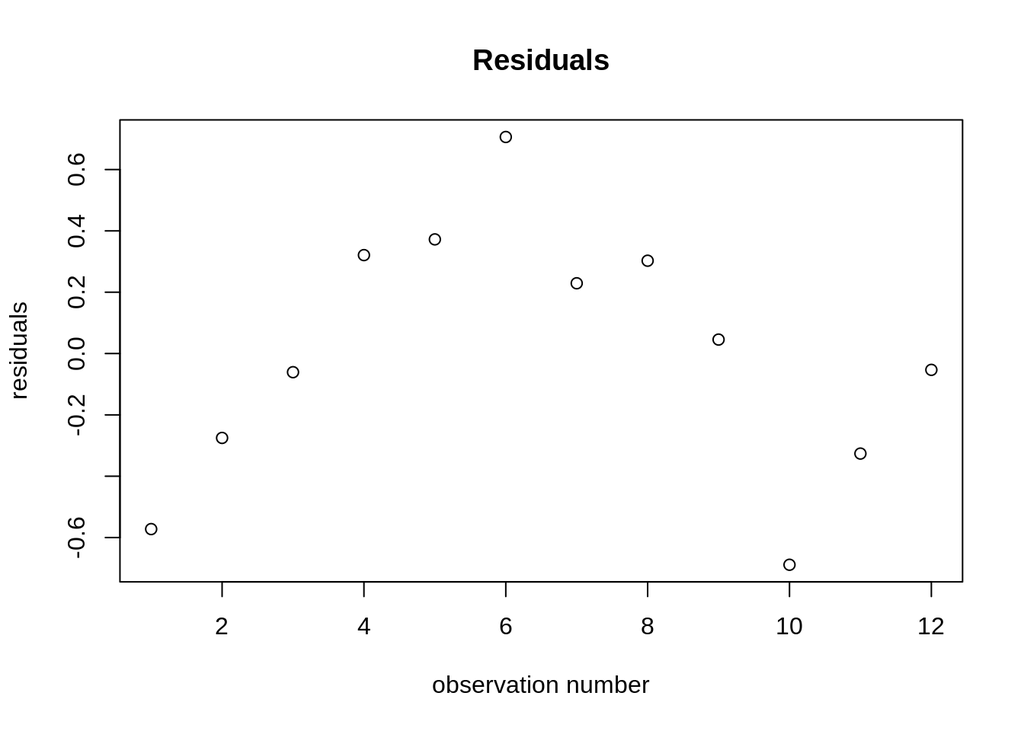

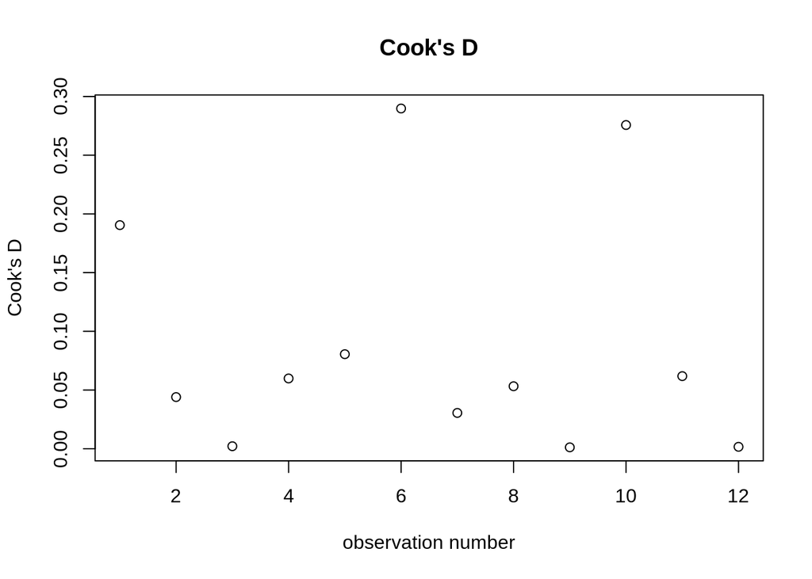

```
## [1] "Inverse ln(intercept): 0.889122002617685"
```

## Second linear regression analysis: assess the importance of replicate

Now we will introduce a variable for the effect of replicate on Z. The results of the linear regression suggest that replicate number does not significantly predict whether baitcap performs better than shotgun for detecting STEC vs. commensal *E. coli*.

```
##
## Call:
## lm(formula = z ~ as.factor(rep), data = d4)
##
## Residuals:
##     Min      1Q  Median      3Q     Max
## -0.5110 -0.3063 -0.1633  0.3671  0.5467
##
## Coefficients:
##                 Estimate Std. Error t value Pr(>|t|)
## (Intercept)      -0.2953     0.2139  -1.380    0.201
## as.factor(rep)2   0.1962     0.3025   0.648    0.533
## as.factor(rep)3   0.3372     0.3025   1.115    0.294
##
## Residual standard error: 0.4279 on 9 degrees of freedom
## Multiple R-squared:  0.1222, Adjusted R-squared:  -0.07283
## F-statistic: 0.6266 on 2 and 9 DF,  p-value: 0.5562
```

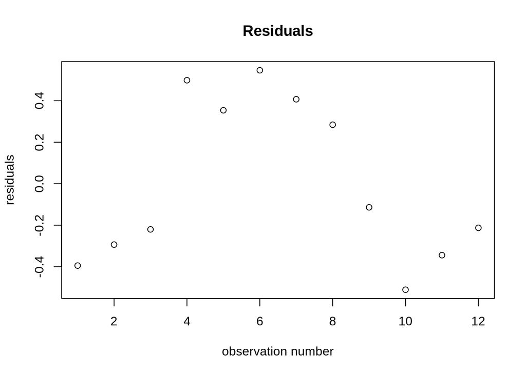

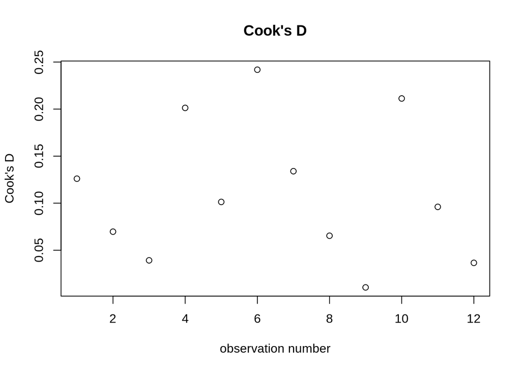

```
## Analysis of Variance Table
##
## Response: z
##                Df  Sum Sq Mean Sq F value Pr(>F)
## as.factor(rep)  2 0.22942 0.11471  0.6266 0.5562
## Residuals       9 1.64756 0.18306
```

## Summary of linear regression analyses

In the figure below, we can see the following minor trend: baitcap performs a little better than shotgun for K vs. C1 and F vs. C1, but a little worse for N vs. C1 and C2 vs. C1. I’d say there is also a trend towards an effect of replicate number, and I would probably change the wet lab methodology if it’s not costly in time or other resources. With larger samples, independent replicates might become a problem. It would be interesting to repeat this analysis with replicates drawn from a single mixture, and compare the results with what we observe here.

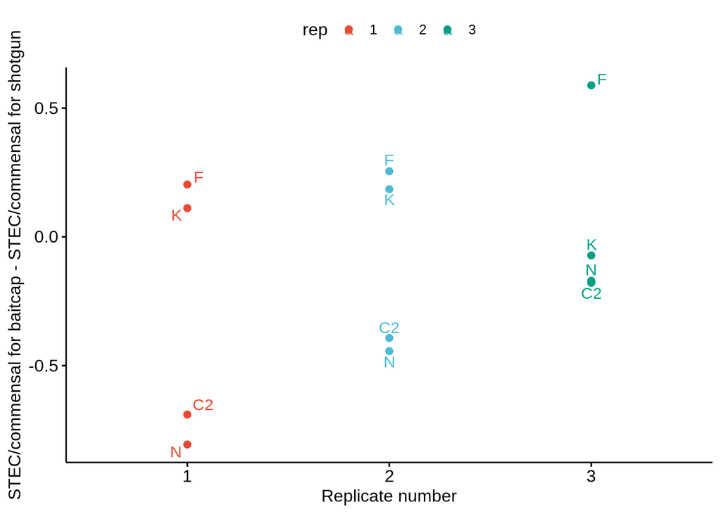